# **Dimensionality Reduction & Multivariate Modeling**

MATH 3190 coursework • Homework 7

Note that your homework should be completed in Quarto. You can just add your answers and code to this document in the appropriate part. The file should be rendered as an html document or pdf document (html is quicker to render and you will need an installation of LaTeX to render as a pdf). You will “turn in” this homework by uploading the files, the .qmd and output file, to your GitHub `Math_3190_Assignment` repository in the `Homework/Homework_7` directory. Make sure all supporting files (if there are any) are in this directory as well. You should use `git` and `Unix` commands in a terminal for this (i.e. don’t manually upload files to GitHub). In addition, you will submit just your html or pdf file on Canvas to unlock the solutions.

Don’t forget to also put a self-critique comment on Canvas indicating what you did correctly and incorrectly and include any questions you may have about the assignment after submitting the assignment and thoroughly looking through the solutions.

# Problem 1 (57 points)

In Homework 6, we briefly looked at a small sample from this data set. Now we have the full data set with 20,640 districts. For districts in California from 1990, we want to predict the median house value for the district based on the district location (longitude and latitude), the median house age in the block group, the total number of rooms in the homes, the total number of bedrooms, the population in the district, the number of households, and the median income (in $10,000). These data were obtained from [scikit-learn.org](https://scikit-learn.org/stable/datasets.html) and can be found in the Data folder of the Math3190_Sp26 GitHub repo with the name `cal_housing.data`.

### Part a (5 points)

Read in the data. The `read.csv()` function works for files that end in `.data` if they are comma separated like this file is. However, be aware that the housing data does not have column names, so make sure to put `header = FALSE`. Assign appropriate column names to the columns and then take logs (base e) of all variables except lat and long. Once this is done, split the data into training and testing sets with the testing containing 20% of the values. Set a seed when you do this.

```r
library(tidyverse)
set.seed(39)
data = read.csv("~/Downloads/cal_housing.data", header = FALSE)
head(data)
```

```
       V1    V2 V3   V4   V5   V6   V7     V8     V9
1 -122.23 37.88 41  880  129  322  126 8.3252 452600
2 -122.22 37.86 21 7099 1106 2401 1138 8.3014 358500
3 -122.24 37.85 52 1467  190  496  177 7.2574 352100
4 -122.25 37.85 52 1274  235  558  219 5.6431 341300
5 -122.25 37.85 52 1627  280  565  259 3.8462 342200
6 -122.25 37.85 52  919  213  413  193 4.0368 269700
```

```r
data = rename(data, Longitude = V1, Latitude = V2, HouseMedAge = V3, TotRooms = V4, TotBedrooms = V5, Pop = V6, Households = V7, MedInc = V8, MedVal = V9)

newdata = data |> mutate(HouseMedAge = log(data$HouseMedAge), TotRooms = log(data$TotRooms), TotBedrooms = log(data$TotBedrooms), Pop = log(data$Pop), Households = log(data$Households), MedInc = log(data$MedInc), MedVal = log(data$MedVal))

train_data = newdata[1:16000, ]
test_data = newdata[16001:20640, ]
```

### Part b (5 points)

Use the following command to view pair-wise scatter plots for the data here. Change `housing_train` to whatever you called the training set and be sure to change the `eval` option for the code chunk to `true`. Note, that `lower` option changes the points to be plotted with periods instead of circles. This speeds up plotting time considerably and makes the plots more readable since there are many data points here.

Based on these plots, does multicollinearity appear to be an issue here? Explain.

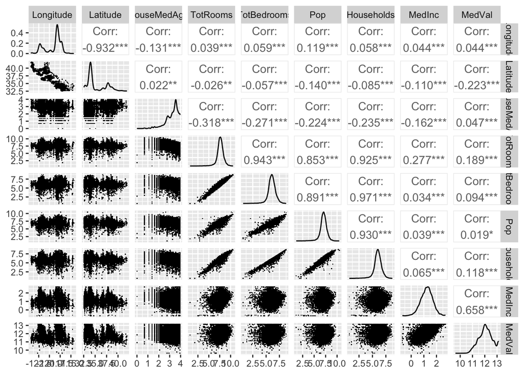

```r
library(GGally)
ggpairs(train_data,
        lower = list(continuous = wrap("points", shape = "."))
)
```

```r
# Yes. Total Rooms is directly correlated with Total Bedrooms, Population, and Household.
```